# Comparison_other_methods

2023-09-21

# Preparation

Firstly, packages required and the example dataset used in the main manuscript are loaded in.

```r
library(sSNAPPY)
library(tidyverse)
library(magrittr)
library(ggplot2)
library(patchwork)
library(AnnotationHub)
library(edgeR)
library(patchwork)
library(colorspace)
library(fgsea)
library(DT)
library(UpSetR)
library(graphite)
library(SPIA)
library(pander)
library(VennDiagram)
```

```r
formatP <- function(p, m = 0.0001){
    out <- rep("", length(p))
    out[p < m] <- sprintf("%.2e", p[p<m])
    out[p >= m] <- sprintf("%.4f", p[p>=m])
    out
}
```

```r
logCPM <- read_tsv(here::here("data/logCPM.tsv")) %>%
    column_to_rownames("entrezid")
sample_meta <- read_tsv(here::here("data/sample_meta.tsv"), col_types = "cfccncnc")
dge <- readRDS(here::here("data/dge.rds"))
```

Reactome pathway topology information was retrieved using the `retrieve_topology` function.

```r
gsTopology <- retrieve_topology(database = "reactome", species = "hsapiens")
```

Chemotherapy-induced significant pathway perturbation that were detected using *sSNAPPY* on group level were loaded in.

```r
sSNAPPY_rs <- read_tsv("data/sSNAPPY_output.tsv")
```

# DE Analysis

Differential expression analysis was performed through `edgeR` to test average gene-level chemotherapy treatment response. Model matrix in the form of `model.matrix(~ 0 + patient_id + treatment_phase, data = dge$samples)` was constructed to nest samples by patients.

```r
X <- model.matrix(~ 0 + patient_id + treatment_phase,
                  data = dge$samples %>%
                      mutate(treatment_phase = factor(treatment_phase, levels = c("treatment-naive", "post-NACT")))
) %>%
    set_colnames(str_remove_all(colnames(.), "patient_id|treatment_phase")) %>%
    .[,colSums(.) != 0]
dge <- estimateDisp(dge, design = X, robust = TRUE)
fit <- glmQLFit(dge)
```

```r
alpha <- 0.05
topTable <- glmQLFTest(fit, coef = "post-NACT") %>%
      topTags(n = Inf) %>%
      .[["table"]] %>%
      as_tibble() %>%
      mutate(
        location = paste0(seqnames, ":", start, "-", end, ":", strand),
        rankingStat = -sign(logFC)*log10(PValue),
        signedRank = rank(rankingStat),
        DE = FDR < alpha
      ) %>%
      dplyr::select(
        gene_id, gene_name, logCPM, logFC, PValue, FDR,
        location, gene_biotype, entrezid, ave_tx_len, gc_content,
        rankingStat, signedRank, DE
      )
DEGs <- topTable %>%
    dplyr::filter(DE)
```

Genes with a FDR < 0.05 were determined to be differentially expressed. 49 DEGs were detected among the 10098 tested genes:

```r
topTable %>%
    dplyr::filter(DE) %>%
    mutate_at(vars(c("PValue", "FDR")), formatP) %>%
    mutate_at(vars(c("logCPM", "logFC")), round, 4) %>%
    dplyr::select(`Gene name` = gene_name,
                  `Gene ID` = gene_id,
                  logCPM, logFC, PValue,
                  FDR) %>%
    mutate_if(is.character, as.factor) %>%
    datatable(
       filter = "top",
       caption = htmltools::tags$caption(
            htmltools::em(
                "Significant changes in gene expression induced by chemotherapy in clinical HGSOC samples.")
        )
    ) %>%
    formatStyle(
        'logFC',
        color = styleInterval(0, c('blue', "red"))
    )
```

|  | Gene name | Gene ID | logCPM | logFC | PValue | FDR |
| --- | --- | --- | --- | --- | --- | --- |
| 1 | RASD1 | ENSG00000108551 | 4.0013 | 1.9237 | 4.22e-07 | 0.0043 |
| 2 | PDK4 | ENSG00000004799 | 4.0686 | 1.6606 | 1.64e-06 | 0.0083 |
| 3 | LHX1 | ENSG00000273706 | 4.5679 | -1.4599 | 2.54e-06 | 0.0085 |
| 4 | HLA-DPB1 | ENSG00000223865 | 6.6799 | 1.6666 | 3.41e-06 | 0.0086 |
| 5 | IGFBP7 | ENSG00000163453 | 7.255 | 1.6944 | 5.73e-06 | 0.0093 |
| 6 | CD14 | ENSG00000170458 | 3.6024 | 1.8616 | 6.35e-06 | 0.0093 |
| 7 | MT1A | ENSG00000205362 | 4.1756 | 2.564 | 6.67e-06 | 0.0093 |
| 8 | S100A1 | ENSG00000160678 | 9.0697 | 1.0978 | 7.91e-06 | 0.0093 |
| 9 | CRYAB | ENSG00000109846 | 9.7846 | 2.0186 | 8.25e-06 | 0.0093 |
| 10 | GADD45B | ENSG00000099860 | 8.4301 | 1.2055 | 1.66e-05 | 0.0168 |

[output cut: 39 more lines]

Among the 49 DEGs, 11 are down-regulated while 38 are up-regulated.

# Pathway analysis using other methods

## GSEA

To perform the gene-set enrichment analysis (GSEA), ranking statistics of each gene were calculated based on the DE analysis results by `-sign(logFC)*log10(PValue)`.

A named vector where the values are the ranking statistic and the names are genes’ entrez id was generated.

```r
load(system.file("extdata", "entrez2name.rda", package = "sSNAPPY"))
temp <- topTable %>%
        mutate(entrezid = paste("ENTREZID:", entrezid, sep = "")) %>%
        drop_na()
ranked_list <- temp %>%
        pull(rankingStat) %>%
        set_names(temp$entrezid)
```

Since GSEA is not a topology-based method, the only pathway information required is genes that are included in each pathway. Therefore, row names of each topology matrix were extracted.

```r
reactome_gs <- sapply(gsTopology, rownames)
```

```r
gsea <-  fgsea(reactome_gs, ranked_list)
gsea_sig <- gsea %>%
    dplyr::filter(padj < 0.05)
```

Using GSEA and a significance cut-off of FDR < 0.05, 239 out of the 1876 tested pathways were considered as significantly enriched, among which 68 pathways were also found to be significantly perturbed by sSNAPPY.

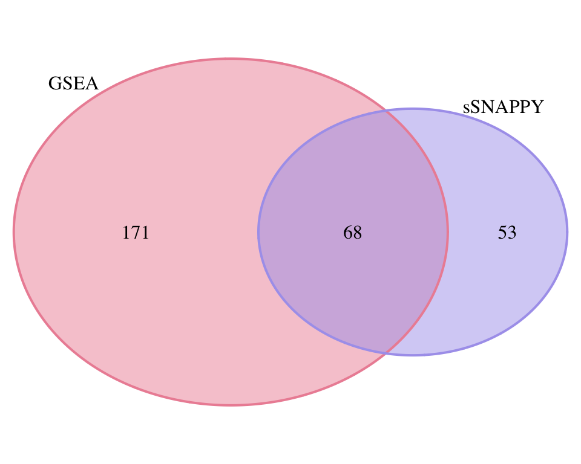

*Overlap between pathways that are considered as significantly impacted by GSEA and sSNAPPY*

```r
grid.newpage()
gsea_venn <- venn.diagram(
    list(
        GSEA = gsea_sig$pathway,
        sSNAPPY = sSNAPPY_rs$gs_name
    ),
    type = "venn", scaled = TRUE, euler.d = TRUE,
    col = c("#ED90A4", "#ACA2EC"),
    fill = c("#ED90A4", "#ACA2EC"),
    filename = NULL,
    cat.pos = c(-40, 30)
)
grid.draw(gsea_venn)
```

## fry

The other non-topology-based method applied to the example dataset is `fry`, which is a fast version of roast (rotation gene set testing). Instead of relying on pre-performed DE analysis results, `fry`/`roast` only requires the logCPM matrix and a design matrix as input.

```r
fry_res <- logCPM %>%
    set_rownames(paste("ENTREZID:", rownames(.), sep = "")) %>%
    fry(
        index = reactome_gs,
        design  = dge$design,
        contrast = "post-NACT",
        sort = "directional"
    ) %>%
  rownames_to_column("Pathway")
fry_sig <- fry_res %>%
    dplyr::filter(FDR < 0.05)
```

Using the directional version of `fry` and the same statistics threshold of FDR < 0.05, 132 pathways were considered as significantly enriched, 44 of which were also considered to be significantly perturbed by `sSNAPPY`.

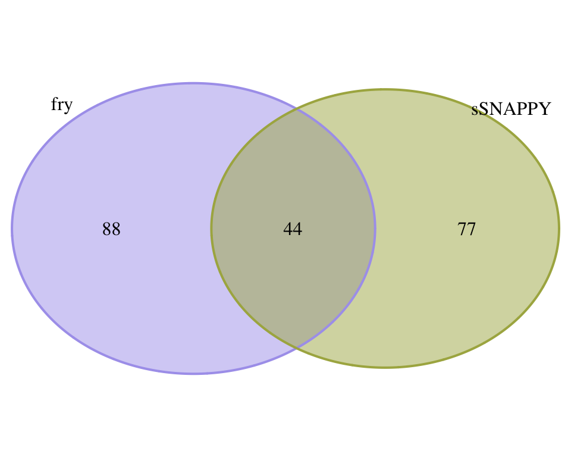

*Overlap between pathways that are considered as significantly impacted by fry and sSNAPPY*

```r
grid.newpage()
fry_venn <- venn.diagram(
    list(
        fry = fry_sig$Pathway,
        sSNAPPY = sSNAPPY_rs$gs_name
    ),
    type = "venn", scaled = TRUE, euler.d = TRUE,
    fill = c("#ACA2EC", "#ABB150"),
    col = c("#ACA2EC", "#ABB150"),
    filename = NULL,
    cat.pos = c(-40, 40)
)
grid.draw(fry_venn)
```

## SPIA

Lastly, the topology-based analysis method `SPIA` was also applied. SPIA requires the the logFCs of differentially expressed genes as an input and has two component: 1) topology-based perturbation analysis and 2) conventional over-representation analysis. Hence, 2 p-values: pPert and pNDE were derived for each pathway, and are combined using the Fisher’s method.

```r
graphite_reactome <- pathways("hsapiens", "reactome")
graphite_reactome <- convertIdentifiers(graphite_reactome, "ENTREZID")
prepareSPIA(graphite_reactome, "graphite_reactome")
DE_vector <- DEGs$logFC %>%
    set_names(paste("ENTREZID:", DEGs$entrezid, sep = ""))
all_entrez <- dge$genes %>%
    unnest(entrezid) %>%
    drop_na() %>%
    pull(entrezid) %>%
    paste("ENTREZID:", ., sep = "")
spia_res <- runSPIA(de = DE_vector, all = all_entrez, "graphite_reactome")
saveRDS(spia_res, here::here("data/spia_res.rds"))
```

```r
spia_res <- readRDS(here::here("data/spia_res.rds"))
```

```r
spia_sig <- spia_res %>%
    dplyr::filter(pGFdr < 0.05) %>%
    mutate(Name = paste("reactome.", Name, sep = ""))
```

By applying a cut-off of 0.05 on the FDR derived from the Fisher p-values, 12 pathways’ activities were considered to be significantly altered. 6 of those pathways were defined to be significantly perturbed by sSNAPPY. It’s important to note that compared to the other methods where all pathways were tested, only 130 pathways were tested by SPIA as pathways that did not contain DEGs were left out.

Most of the pathways that were considered as significantly impacted by *SPIA* are immune-related process. Compared to other methods, sPIA showed a lack of power in detecting significant pathway perturbation.

```r
spia_sig %>%
    dplyr::select(
        Pathway = Name, pNDE,  pPERT, pGFdr, Status) %>%
    pander(
        caption = "Reactome pathways that were considered as significantly impacted
        by chemotherapy throguh SPIA"
    )
```

Reactome pathways that were considered as significantly impacted by chemotherapy throguh SPIA

| Pathway | pNDE | pPERT | pGFdr | Status |
| --- | --- | --- | --- | --- |
| reactome.Phosphorylation of CD3 and TCR zeta chains | 1.898e-12 | 0.001 | 5.628e-12 | Activated |
| reactome.Translocation of ZAP-70 to Immunological synapse | 6.398e-14 | 0.046 | 5.628e-12 | Activated |
| reactome.PD-1 signaling | 1.898e-12 | 0.002 | 5.628e-12 | Activated |
| reactome.Interferon gamma signaling | 1.268e-11 | 0.83 | 8.987e-09 | Activated |
| reactome.Generation of second messenger molecules | 2.676e-11 | 1 | 1.763e-08 | Inhibited |
| reactome.Interferon Signaling | 2.082e-09 | 0.397 | 3.925e-07 | Inhibited |
| reactome.MHC class II antigen presentation | 8.671e-08 | 0.136 | 4.217e-06 | Activated |
| reactome.Downstream TCR signaling | 1.955e-06 | 0.146 | 7.453e-05 | Inhibited |
| reactome.TCR signaling | 3.941e-06 | 0.449 | 0.0003641 | Inhibited |
| reactome.Diseases of Immune System | 3.698e-05 | 1 | 0.004897 | Inhibited |
| reactome.Defects in Toll-like Receptor Cascades | 3.698e-05 | 1 | 0.004897 | Inhibited |
| reactome.Interferon alpha/beta signaling | 0.002201 | 0.019 | 0.00502 | Inhibited |

# Comparison

Various numbers of significance were detected using each pathway analysis method, with the highest number of significance returned by GSEA.

```r
allMethod_sig <- list(
        sSNAPPY = sSNAPPY_rs$gs_name,
        GSEA = gsea_sig$pathway,
        fry = fry_sig$Pathway,
        SPIA = spia_sig$Name
    )
allMethod_sig %>%
    vapply(length, numeric(1)) %>%
    enframe(
        name = "Method",
        value = "Number of significance"
    ) %>%
    arrange(`Number of significance`) %>%
    pander(
        caption = "Number of significantly impacted Reactome pathways found by each pathway analysis method."
    )
```

Number of significantly impacted Reactome pathways found by each pathway analysis method.

| Method | Number of significance |
| --- | --- |
| SPIA | 12 |
| sSNAPPY | 121 |
| fry | 132 |
| GSEA | 239 |

Pathways considered to be significantly impacted by each analysis method were intersected.

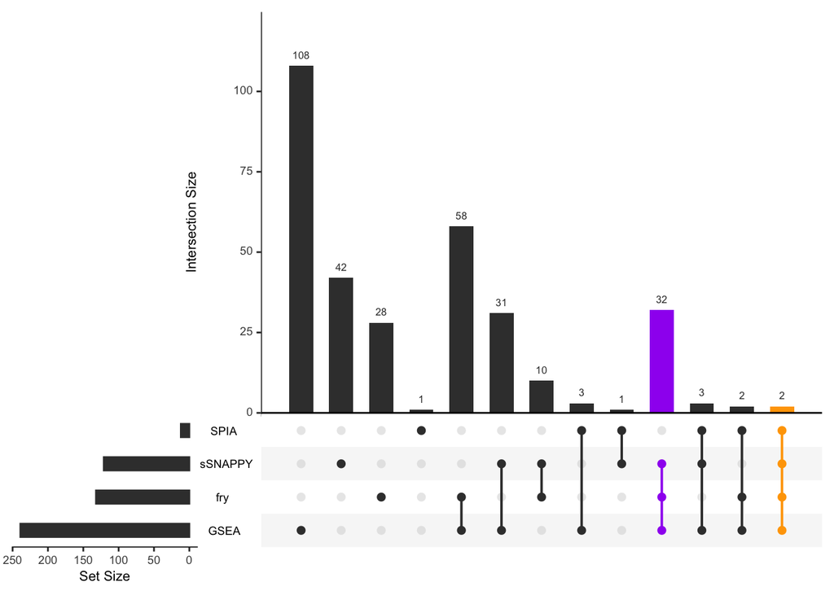

```r
allMethod_sig %>%
    fromList() %>%
    upset(
        sets = colnames(.),
        nintersects = NA,
        queries = list(
          list(query = intersects,
               params = list(names(allMethod_sig)),
               color = "orange",
               active = T),
          list(query = intersects,
               params = list(names(allMethod_sig)[-4]),
               color = "purple",
               active = T)
        )
    )
```

2 pathways: Translocation of ZAP-70 to Immunological synapse and Generation of second messenger molecules were found to be significantly impacted by the chemotherapy by all methods, and 32 pathways were significant in results returned by *sSNAPPY*, *fry* and *GSEA*. The DNA damage response and repair pathway **SUMOylation of DNA damage response and repair proteins** was reported in the original study and considered as significantly impacted by all 3 methods: *sSNAPPY*, *fry* and *GSEA*. However, only *sSNAPPY* is capable of accounting for gene-gene interaction to predict the directionality of change in pathway acitvities.

```r
overlap_3methods <- allMethod_sig[c("GSEA", "fry", "sSNAPPY")] %>%
    Reduce(intersect,.) %>%
    setdiff(., allMethod_sig$SPIA)
str_remove_all(overlap_3methods, "reactome.")
```

```
##  [1] "Antiviral mechanism by IFN-stimulated genes"
##  [2] "Chromatin modifying enzymes"
##  [3] "Chromatin organization"
##  [4] "Condensation of Prometaphase Chromosomes"
##  [5] "Deubiquitination"
##  [6] "Epigenetic regulation of gene expression"
##  [7] "ISG15 antiviral mechanism"
##  [8] "Major pathway of rRNA processing in the nucleolus and cytosol"
##  [9] "Metabolism of RNA"
## [10] "Mitotic Prophase"
## [11] "Nuclear Envelope Breakdown"
## [12] "Nuclear Pore Complex (NPC) Disassembly"
## [13] "Phosphorylation of Emi1"
## [14] "Phosphorylation of the APC/C"
## [15] "RMTs methylate histone arginines"
```

[output cut: 17 more lines]